# PAP Fimbrial Major Pilin Protein

## Figure 6: Deep-MSA contact map panel / Best clusters contact map panel

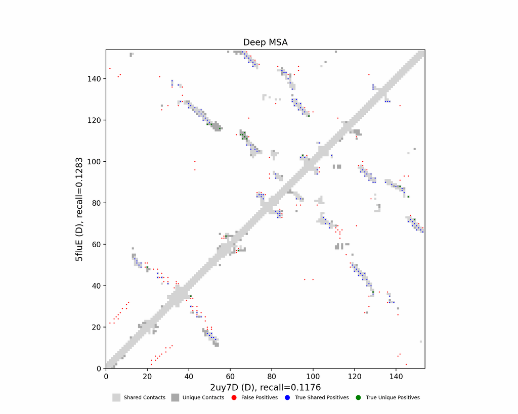

Deep-MSA contact map panel

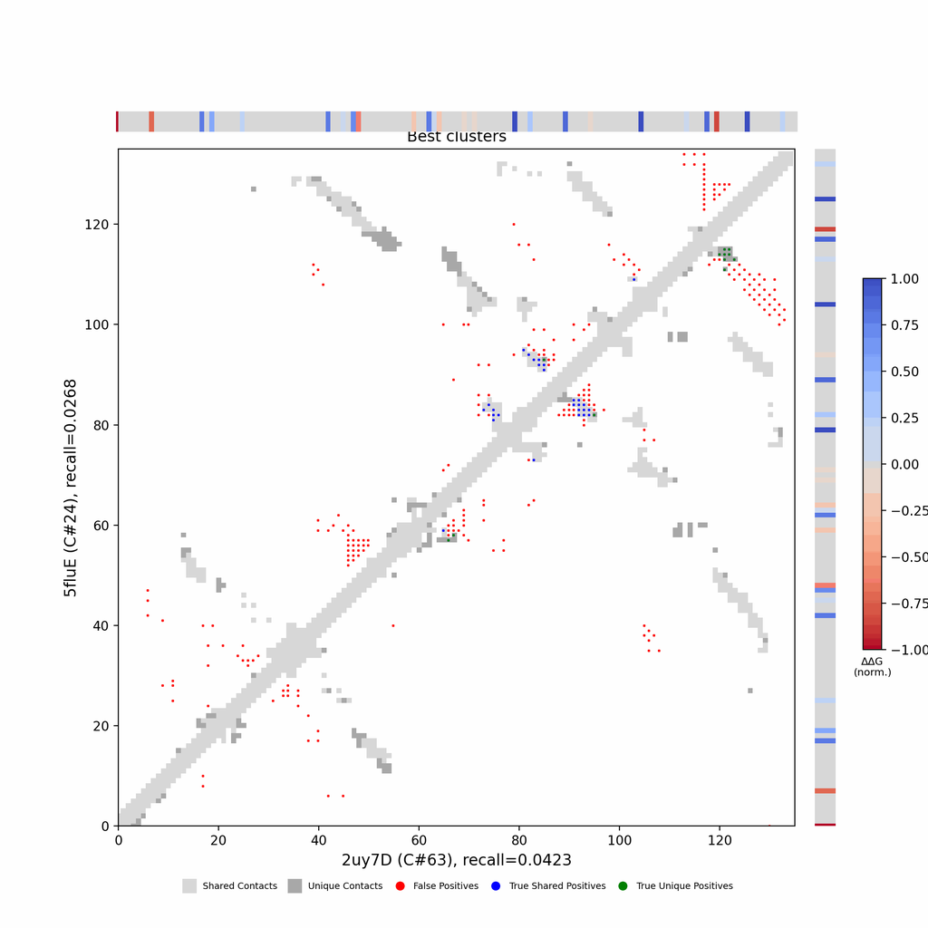

Best clusters contact map panel

## Figure 7: All clusters contact-map mosaic (small multiples).

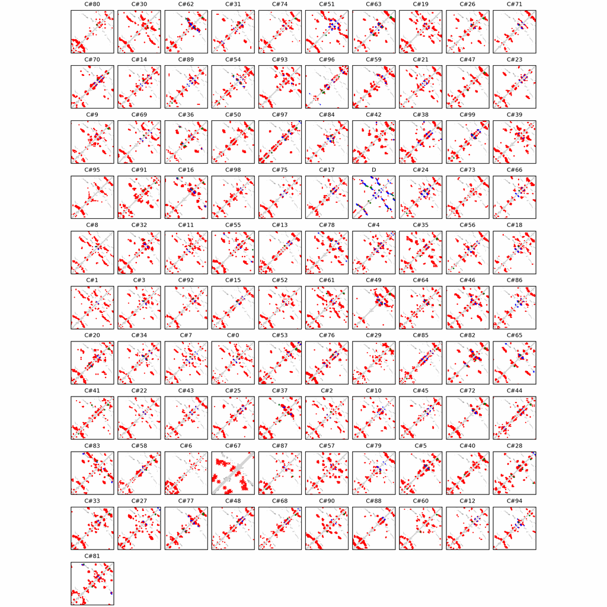

## Figure 8: Phylo null: tree with shuffled cluster fold labels.

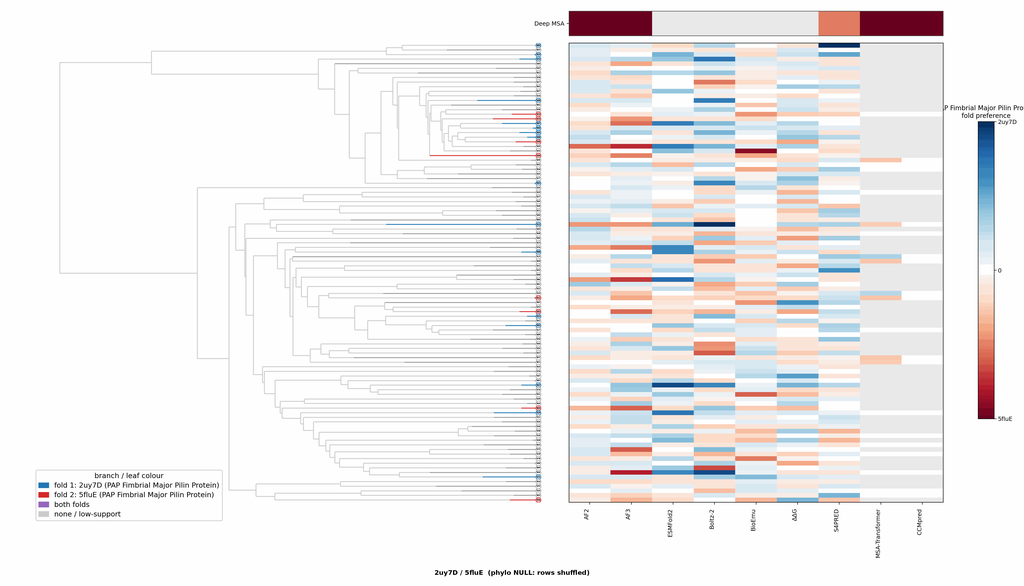

## Cluster metrics table

Per-cluster metrics underlying the figures above.

| cluster | n | neff | AF2_TM1 | AF2_TM2 | AF3_TM1 | AF3_TM2 | RE-MSAT-COM | RE-MSAT1 | RE-MSAT2 | ESM_SEQIDS | ESM_TM1 | ESM_TM2 | ΔΔG_Bias | ΔΔG_Bias_std | ΔΔG_frac_F1 | Boltz2_pref | S4PRED_pref | CCMpred_pref | BioEmu_pref |
| --- | --- | --- | --- | --- | --- | --- | --- | --- | --- | --- | --- | --- | --- | --- | --- | --- | --- | --- | --- |
| Deep | - | - | 0.75 | 0.93 | 0.75 | 0.92 | 0.4 | 0.37 | 0.39 | - | - | - | - | - | - | - | -0.06 | -0.0 | - |
| 000 | 590.0 | 223.0 | 0.36 | 0.39 | 0.38 | 0.4 | 0.02 | 0.02 | 0.02 | 004; 004; 006; 006; 003; 003; 005; 005; 001; 007 | 0.69 ± 0.02 | 0.73 ± 0.02 | 1.53 | 2.84 | 0.8 | -0.0 | -0.03 | 0.0 | 0.02 |
| 001 | 258.0 | 89.0 | 0.54 | 0.54 | 0.61 | 0.63 | 0.01 | 0.01 | 0.01 | 002; 002; 010; 010; 005; 005; 001; 001; 007; 003 | 0.70 ± 0.02 | 0.74 ± 0.02 | 1.91 | 2.95 | 0.5 | 0.01 | -0.06 | 0.0 | 0.01 |
| 002 | 253.0 | 89.0 | 0.45 | 0.41 | 0.48 | 0.45 | 0.01 | 0.01 | 0.01 | 008; 007; 005; 008; 005; 007; 006; 006; 001; 004 | 0.71 ± 0.01 | 0.72 ± 0.02 | 4.66 | 2.99 | 0.9 | -0.01 | -0.05 | 0.0 | 0.02 |
| 003 | 125.0 | 37.0 | 0.32 | 0.3 | 0.57 | 0.56 | 0.01 | 0.01 | 0.01 | 004; 004; 005; 006; 006; 009; 009; 005; 007; 003 | 0.69 ± 0.01 | 0.74 ± 0.02 | 3.75 | 2.51 | 0.9 | 0.04 | -0.06 | 0.0 | 0.02 |
| 004 | 106.0 | 27.0 | 0.43 | 0.44 | 0.75 | 0.75 | 0.01 | 0.01 | 0.01 | 006; 006; 003; 003; 007; 007; 002; 002; 005; 005 | 0.69 ± 0.01 | 0.74 ± 0.02 | 1.18 | 2.98 | 0.6 | 0.07 | -0.01 | 0.0 | -0.0 |
| 005 | 105.0 | 37.0 | 0.36 | 0.39 | 0.66 | 0.72 | 0.02 | 0.02 | 0.01 | 001; 001; 008; 008; 009; 009; 003; 003; 007; 007 | 0.73 ± 0.01 | 0.76 ± 0.02 | 2.56 | 2.27 | 0.9 | -0.02 | 0.0 | 0.0 | 0.02 |
| 006 | 90.0 | 36.0 | 0.63 | 0.64 | 0.74 | 0.9 | 0.0 | 0.0 | 0.0 | 001; 001; 005; 005; 002; 002; 006; 003; 003; 006 | 0.72 ± 0.03 | 0.78 ± 0.03 | 2.0 | 2.67 | 0.8 | 0.02 | -0.06 | 0.0 | 0.01 |
| 007 | 84.0 | 41.0 | 0.44 | 0.47 | 0.55 | 0.58 | 0.01 | 0.01 | 0.01 | 010; 010; 008; 002; 002; 008; 007; 005; 001; 007 | 0.69 ± 0.02 | 0.73 ± 0.03 | 2.66 | 3.3 | 0.7 | 0.02 | -0.05 | 0.0 | 0.01 |
| 008 | 81.0 | 27.0 | 0.4 | 0.37 | 0.63 | 0.66 | 0.01 | 0.01 | 0.01 | 003; 007; 007; 003; 010; 008; 008; 010; 009; 009 | 0.68 ± 0.01 | 0.72 ± 0.02 | 2.65 | 2.96 | 0.8 | -0.0 | -0.06 | 0.0 | 0.0 |
| 009 | 81.0 | 29.0 | 0.4 | 0.38 | 0.5 | 0.54 | 0.0 | 0.01 | 0.0 | 008; 008; 005; 003; 003; 004; 005; 004; 001; 001 | 0.69 ± 0.02 | 0.74 ± 0.01 | 2.73 | 3.06 | 0.8 | -0.03 | -0.03 | 0.0 | 0.04 |
| 010 | 80.0 | 27.0 | 0.33 | 0.3 | 0.66 | 0.72 | 0.0 | 0.0 | 0.0 | 001; 006; 006; 003; 001; 003; 007; 007; 004; 004 | 0.68 ± 0.01 | 0.72 ± 0.02 | 2.9 | 2.56 | 0.9 | 0.0 | -0.03 | 0.0 | 0.01 |
| 011 | 77.0 | 35.0 | 0.37 | 0.39 | 0.66 | 0.75 | 0.0 | 0.0 | 0.01 | 009; 009; 002; 002; 001; 008; 008; 001; 006; 005 | 0.69 ± 0.02 | 0.73 ± 0.02 | 1.73 | 1.5 | 0.8 | 0.01 | -0.02 | 0.0 | 0.03 |
| 012 | 73.0 | 39.0 | 0.66 | 0.74 | 0.7 | 0.8 | 0.02 | 0.01 | 0.01 | 002; 008; 005; 007; 007; 008; 005; 002; 001; 009 | 0.70 ± 0.01 | 0.73 ± 0.01 | 5.58 | 2.64 | 1.0 | 0.04 | -0.01 | 0.0 | 0.02 |
| 013 | 72.0 | 27.0 | 0.52 | 0.52 | 0.6 | 0.64 | 0.02 | 0.01 | 0.02 | 008; 008; 001; 003; 010; 001; 003; 010; 004; 004 | 0.69 ± 0.01 | 0.69 ± 0.02 | 1.17 | 2.98 | 0.5 | 0.01 | -0.07 | 0.0 | -0.02 |
| 014 | 71.0 | 19.0 | 0.3 | 0.29 | 0.24 | 0.22 | 0.02 | 0.01 | 0.01 | 002; 002; 003; 003; 009; 009; 001; 007; 005; 001 | 0.70 ± 0.01 | 0.74 ± 0.01 | 4.38 | 2.75 | 1.0 | 0.02 | -0.04 | 0.0 | 0.0 |
| 015 | 68.0 | 19.0 | 0.48 | 0.5 | 0.62 | 0.58 | 0.01 | 0.01 | 0.01 | 005; 005; 001; 001; 004; 004; 007; 010; 002; 002 | 0.68 ± 0.01 | 0.70 ± 0.01 | 3.4 | 2.86 | 0.9 | -0.02 | -0.01 | 0.0 | -0.0 |
| 016 | 68.0 | 24.0 | 0.33 | 0.32 | 0.37 | 0.37 | 0.04 | 0.04 | 0.04 | 008; 008; 001; 001; 007; 009; 010; 007; 009; 010 | 0.68 ± 0.02 | 0.73 ± 0.02 | 4.18 | 2.73 | 0.9 | 0.01 | -0.04 | 0.0 | 0.02 |
| 017 | 68.0 | 15.0 | 0.46 | 0.48 | 0.73 | 0.74 | 0.01 | 0.01 | 0.01 | 004; 010; 004; 003; 010; 009; 009; 006; 001; 006 | 0.71 ± 0.01 | 0.73 ± 0.02 | 3.35 | 2.75 | 1.0 | 0.02 | -0.02 | 0.0 | 0.02 |
| 018 | 67.0 | 26.0 | 0.56 | 0.53 | 0.7 | 0.77 | 0.01 | 0.01 | 0.01 | 001; 007; 007; 002; 002; 001; 009; 004; 004; 009 | 0.69 ± 0.00 | 0.73 ± 0.01 | 1.43 | 3.08 | 0.6 | 0.07 | -0.04 | 0.0 | 0.01 |
| 019 | 66.0 | 32.0 | 0.4 | 0.36 | 0.37 | 0.35 | 0.0 | 0.0 | 0.0 | 008; 008; 010; 006; 010; 006; 004; 002; 002; 004 | 0.68 ± 0.01 | 0.72 ± 0.01 | 3.27 | 1.85 | 1.0 | 0.03 | -0.06 | 0.0 | 0.0 |
| 020 | 66.0 | 17.0 | 0.33 | 0.35 | 0.48 | 0.48 | 0.0 | 0.0 | 0.0 | 007; 007; 010; 004; 005; 006; 006; 010; 002; 002 | 0.68 ± 0.00 | 0.71 ± 0.02 | 0.33 | 2.94 | 0.6 | -0.01 | -0.03 | 0.0 | 0.01 |
| 021 | 65.0 | 26.0 | 0.43 | 0.43 | 0.43 | 0.41 | 0.0 | 0.0 | 0.0 | - | - | - | -0.04 | 2.06 | 0.6 | 0.0 | -0.02 | - | 0.02 |
| 022 | 63.0 | 28.0 | 0.44 | 0.46 | 0.69 | 0.72 | 0.01 | 0.01 | 0.01 | - | - | - | 1.24 | 3.29 | 0.6 | -0.0 | -0.05 | - | 0.02 |
| 023 | 62.0 | 25.0 | 0.53 | 0.51 | 0.59 | 0.6 | 0.03 | 0.03 | 0.03 | - | - | - | 4.98 | 2.72 | 1.0 | -0.0 | 0.01 | - | 0.02 |
| 024 | 62.0 | 22.0 | 0.44 | 0.45 | 0.66 | 0.72 | 0.03 | 0.02 | 0.03 | - | - | - | 1.66 | 1.46 | 0.9 | -0.01 | -0.04 | - | 0.01 |
| 025 | 61.0 | 16.0 | 0.62 | 0.6 | 0.42 | 0.41 | 0.02 | 0.01 | 0.01 | - | - | - | 4.1 | 1.94 | 1.0 | 0.02 | -0.05 | - | 0.02 |
| 026 | 59.0 | 19.0 | 0.46 | 0.46 | 0.33 | 0.32 | 0.0 | 0.01 | 0.01 | - | - | - | 1.92 | 2.62 | 0.7 | 0.02 | -0.04 | - | 0.01 |
| 027 | 58.0 | 10.0 | 0.41 | 0.38 | 0.63 | 0.67 | 0.0 | 0.0 | 0.0 | - | - | - | 3.21 | 2.45 | 0.8 | 0.02 | -0.04 | - | 0.0 |
| 028 | 58.0 | 6.0 | 0.47 | 0.49 | 0.65 | 0.7 | 0.0 | 0.0 | 0.01 | - | - | - | 4.18 | 2.15 | 0.9 | 0.01 | -0.06 | - | 0.01 |

[output cut: 71 more lines]